# Data Visualization Part I: Exploratory Graphics

We can do that using the fill= option in the aes() function:

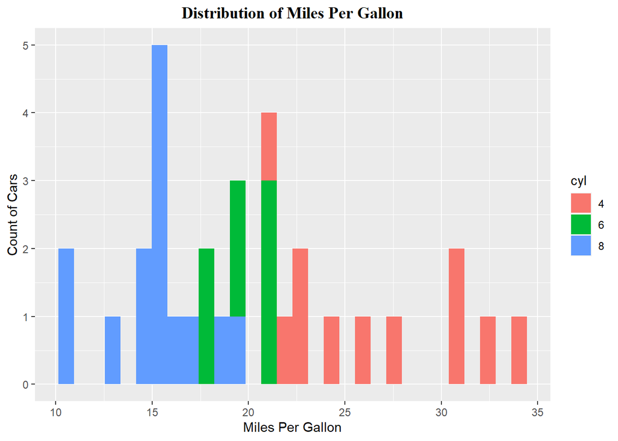

```r
ggplot(mtcars, aes(x=mpg, fill=cyl)) + geom_histogram() +
  ggtitle("Distribution of Miles Per Gallon") +
  theme(plot.title=element_text(hjust=0.5,
                                face="bold", family="serif")) +
  xlab("Miles Per Gallon") +
  ylab("Count of Cars")
```

Well, that’s a bit messy. It’s hard to tell when a bar overlaps another bar entirely or only partially. It looks like R tries to do it’s best to communicate that, but it remains unclear.

We can fix that by adjusting the opacity of the bars themselves so they are slightly see-through. That way, we can see the overlap more clearly.

To accomplish this, we need to use both the position= and alpha= options within the geom_histogram() function.

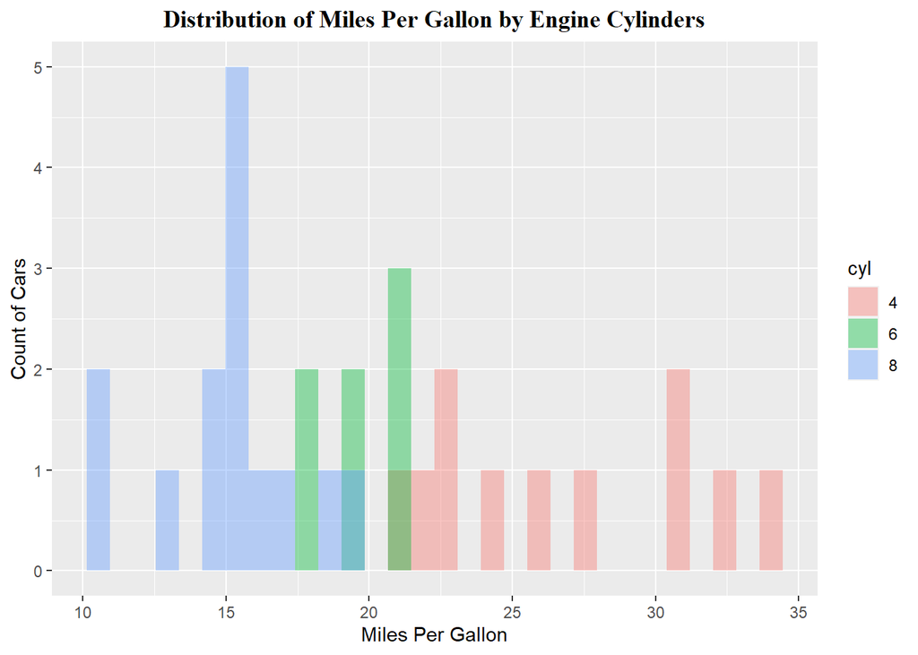

```r
ggplot(mtcars, aes(x=mpg, fill=cyl)) +
  geom_histogram(position="identity", alpha=0.4) +
  ggtitle("Distribution of Miles Per Gallon by Engine Cylinders") +
  theme(plot.title=element_text(hjust=0.5,
                                face="bold", family="serif")) +
  xlab("Miles Per Gallon") +
  ylab("Count of Cars")
```

The position=“identity” option suppresses R behavior that prioritizes the most recent bar plotted in a position while the alpha=0.4 option makes the bars less opaque.

The value provided to the alpha option can range from 0 (completely transparent) to 1 (completely opaque). You can enter values outside this range, but they won’t have any additional effect, to my knowledge.

#### A Close Relative of the Histogram, the Density Curve

Before we move on to boxplots, I want to show you a close cousin of the histogram - a density curve. Density curves can be a bit cleaner than a histogram while conveying similar information.

The height of the curve is a density, meaning that values at that place in the distribution are more likely to occur than other values. Much like a normal distribution, you can estimate probabilities by adding the densities across ranges of values (but we are not going to do that today).

Let’s take a look at the same histogram as above, but this time as a density curve:

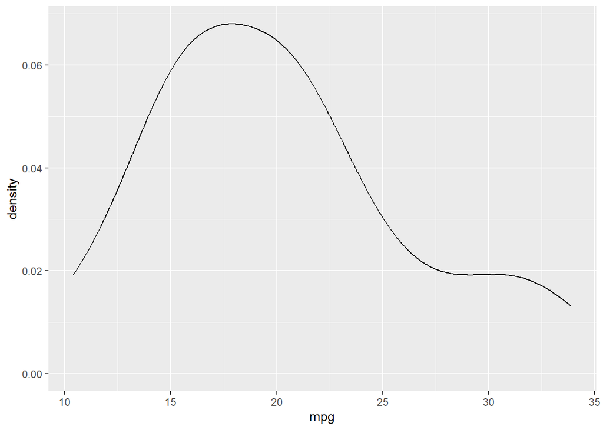

```r
ggplot(mtcars, aes(x=mpg)) + geom_density()
```

Looks pretty boring. Let’s add some features to round it out.

The first thing I am going to do is to reduce how much smoothing is going on here. Basically, a density plot will smooth the distribution so it’s less box-like. When it’s too smooth, it makes the distribution seem much more continuous than it really is.

We can use the bw= option within the geom_density() function:

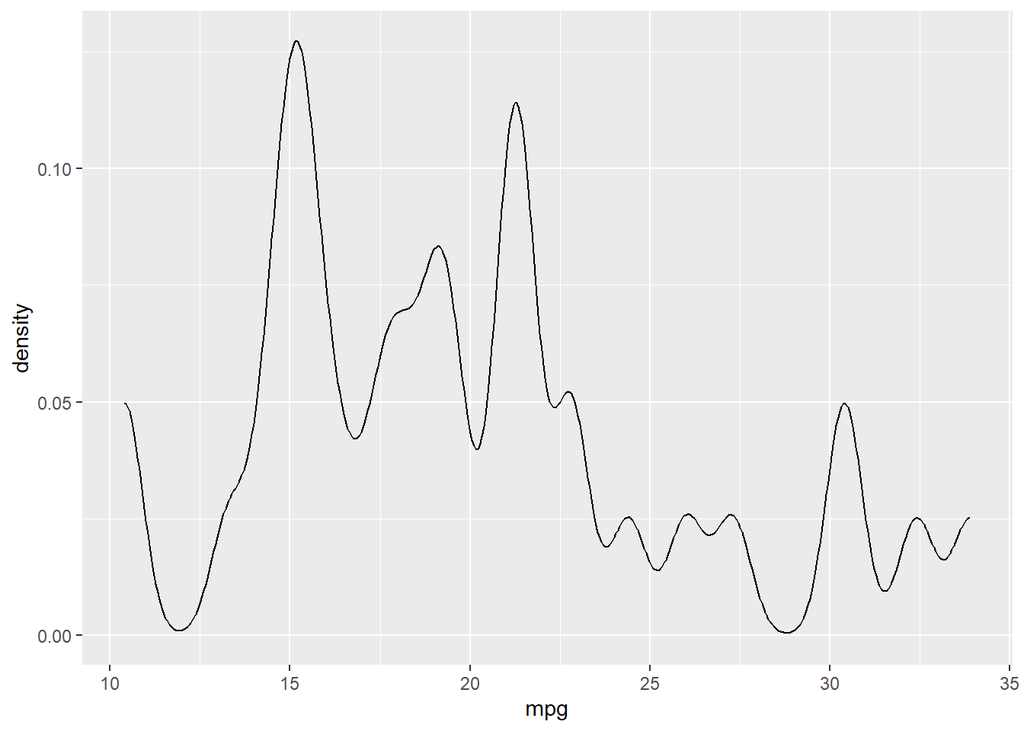

```r
ggplot(mtcars, aes(x=mpg)) + geom_density(bw=0.5)
```

That looks a little more representative of what we saw in the histogram. Briefly, the bw= option changes the standard deviation of the smoothing process - all else equal, smaller values will result in less-smoothed densities (which is usually what I go for).

Now, let’s add another variable to this:

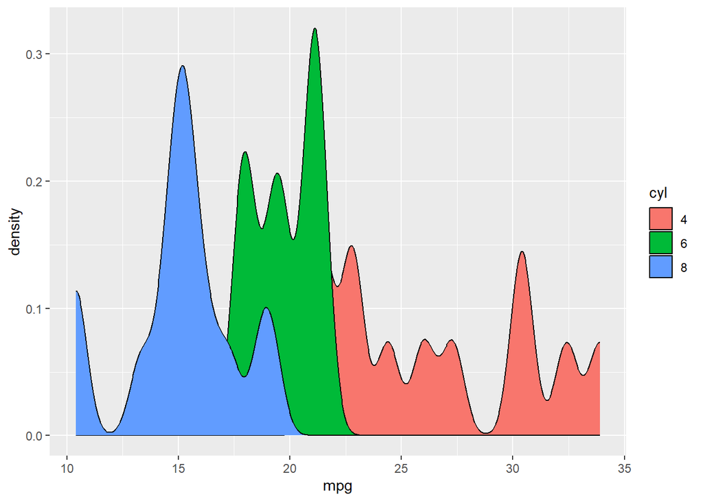

```r
ggplot(mtcars, aes(x=mpg, fill=cyl)) + geom_density(bw=0.5)
```

That’s starting to look pretty neat, but like the histogram, the overlap obscures some of the parts of each distribution. Let’s fix that with the alpha= option like we did before.

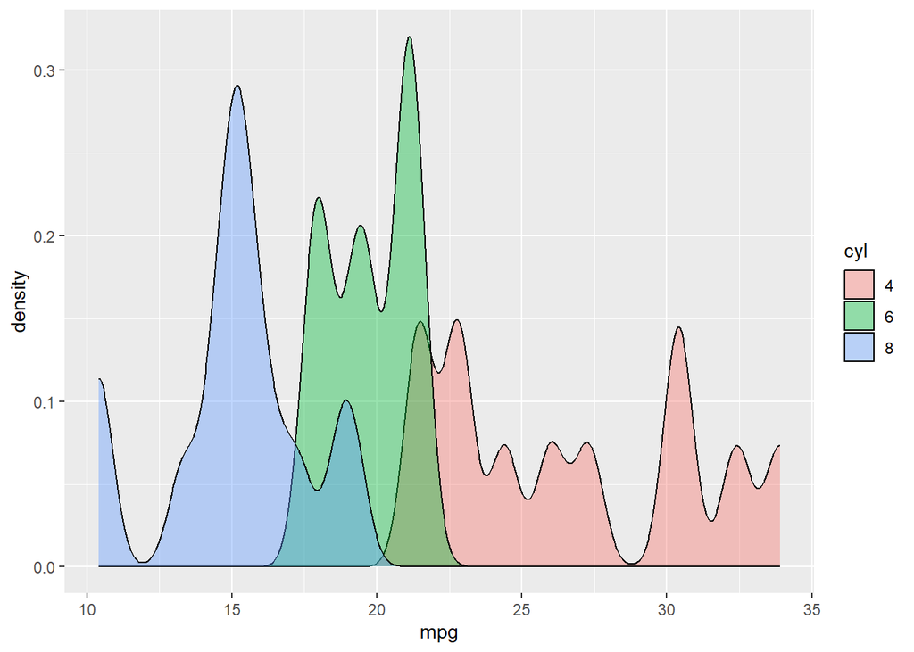

```r
ggplot(mtcars, aes(x=mpg, fill=cyl)) + geom_density(bw=0.5, alpha=0.4)
```

Much better. Now, let’s add proper titles to finish this one up.

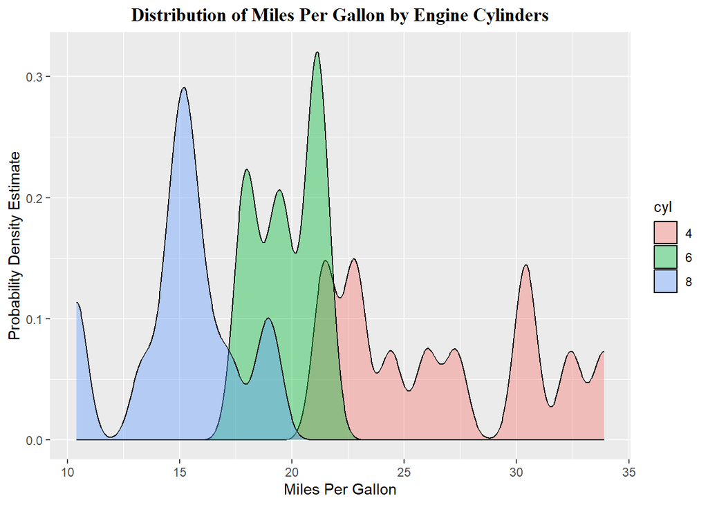

```r
ggplot(mtcars, aes(x=mpg, fill=cyl)) + geom_density(bw=0.5, alpha=0.4) +
  ggtitle("Distribution of Miles Per Gallon by Engine Cylinders") +
  theme(plot.title=element_text(hjust=0.5,
                                face="bold", family="serif")) +
  xlab("Miles Per Gallon") +
  ylab("Probability Density Estimate")
```

#### But Wait, Can We Combine Those Graphs?!?

Yes, you can!

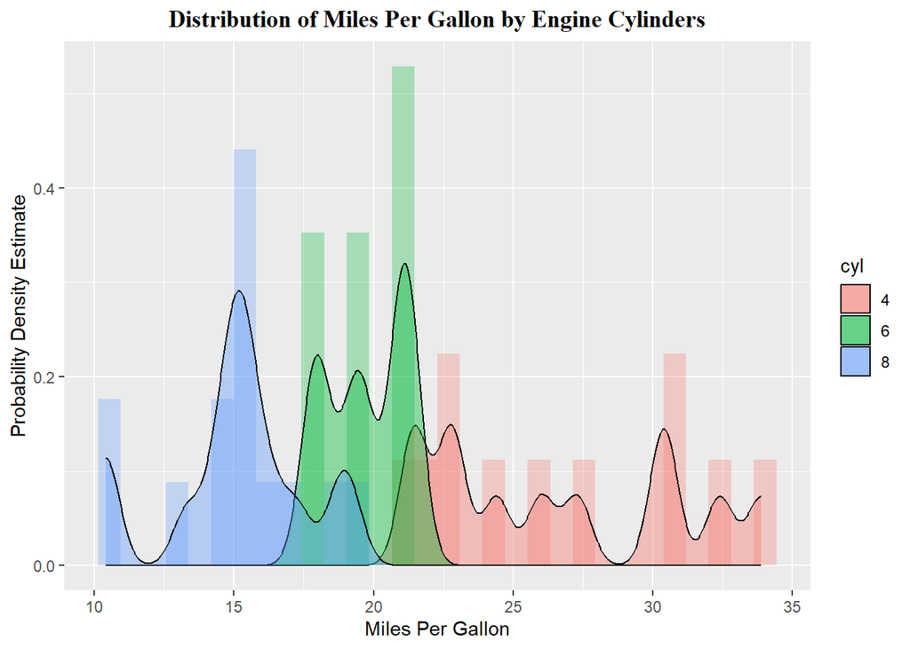

```r
ggplot(mtcars, aes(x=mpg, y=after_stat(density), fill=cyl)) +
  geom_histogram(position="identity", alpha=0.3) +
  geom_density(bw=0.5, alpha=0.4) +
  ggtitle("Distribution of Miles Per Gallon by Engine Cylinders") +
  theme(plot.title=element_text(hjust=0.5,
                                face="bold", family="serif")) +
  xlab("Miles Per Gallon") +
  ylab("Probability Density Estimate")
```

This can be pretty helpful when comparing distributions across multiple categories of another variable, especially when overlap in distributions is something you care about.

## Boxplots

Boxplots are an excellent visualization tool that tells you a lot about a distribution in just one figure. These are also very helpful for comparing distributions across a categorical variable and will tell you quite a bit about the central tendency and dispersion of these different distributions.

Boxplots are also known as box-and-whisker plots. The top and bottom of each box represents the 75th and 25th percentiles, respectively while the horizontal line within the box represents the median.

The whiskers extending above and below the box can represent different things. One method of drawing the whiskers is just to have them extend to the minimum and maximum value of the distribution.

The other, more common, method is to draw the lines up and down by 1.5 times the interquartile range value. All values below or above that upper/lower limit are defined as outliers.

Most statistical packages use the 1.5*IQR method.

Let’s return to miles per gallon again and see what the distribution looks like in a boxplot:

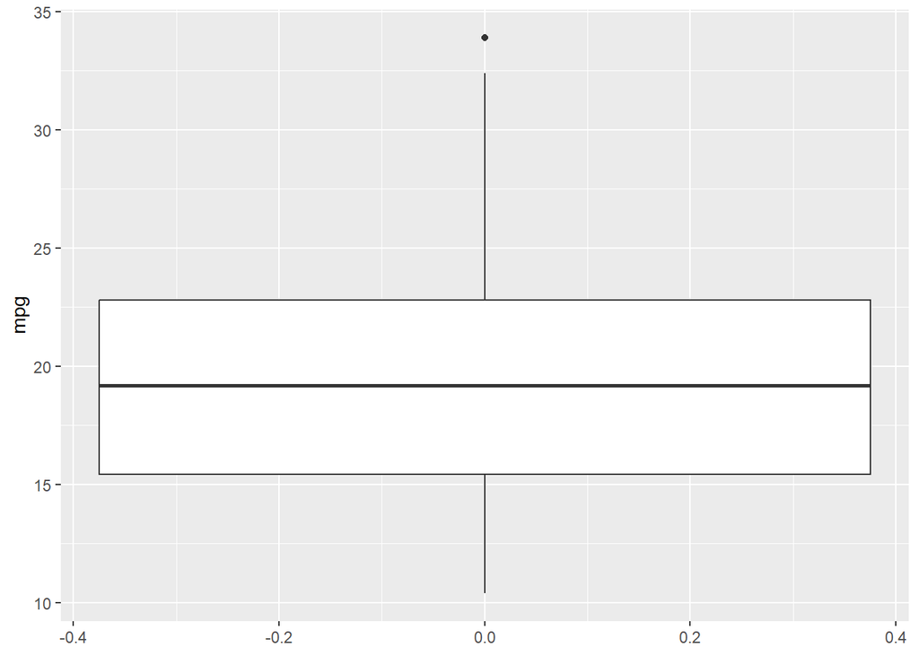

```r
ggplot(mtcars, aes(y=mpg)) + geom_boxplot()
```

While we can understand a few things about the distribution from this picture (the median, IQR, minimum, presence of outliers), boxplots are a bit more helpful when **comparing** different distributions.

Let’s add cylinders to the plot again to see how it changes:

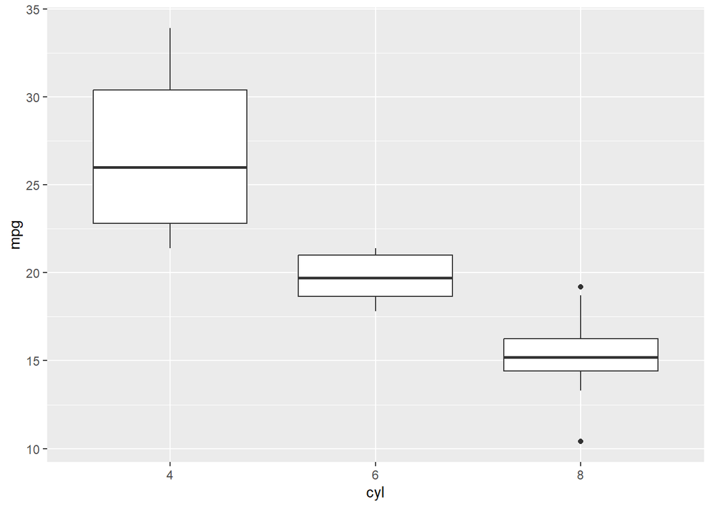

```r
ggplot(mtcars, aes(x=cyl, y=mpg)) + geom_boxplot()
```

Now we’re getting somewhere! We can now see something similar to what we saw in the histogram and density curve, though now we have a bit more information about how the distributions overlap with respect to the percentiles of these distributions.

Let’s make a few changes to the plots to emphasize these differences. First, I’ll make reduce the width of the boxes.

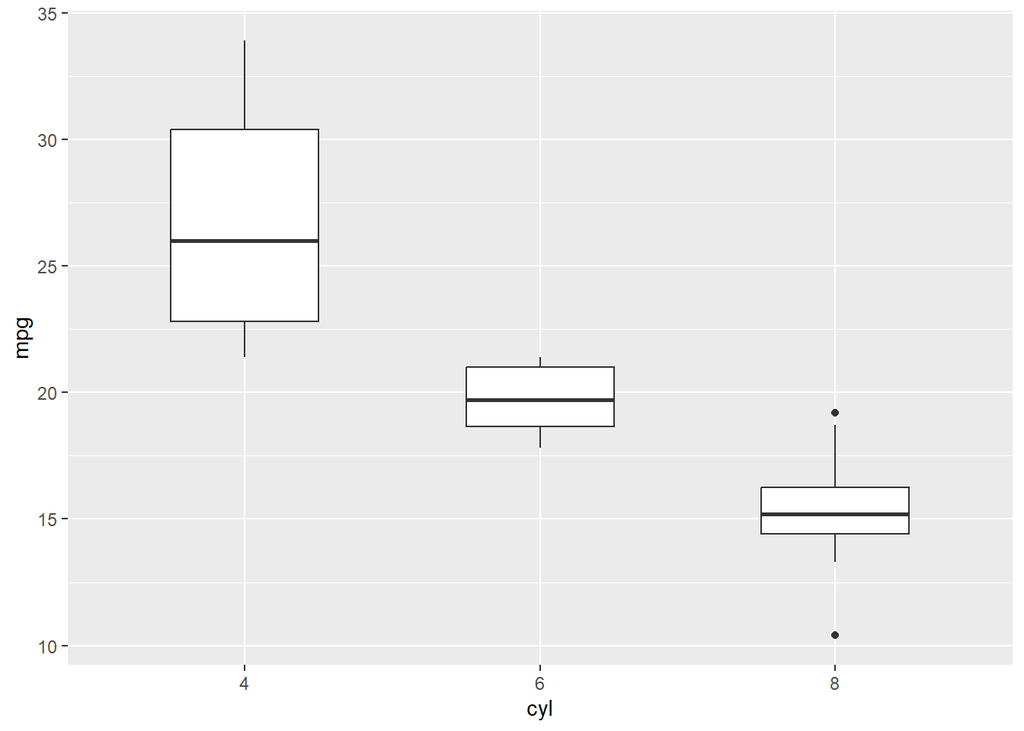

```r
ggplot(mtcars, aes(x=cyl, y=mpg)) +
  geom_boxplot(width=0.5)
```

The width of the boxes is better now as they seem less stretched out, but there’s definitely more we can do.

Let’s add the actual observations as dots using the geom_jitter() function:

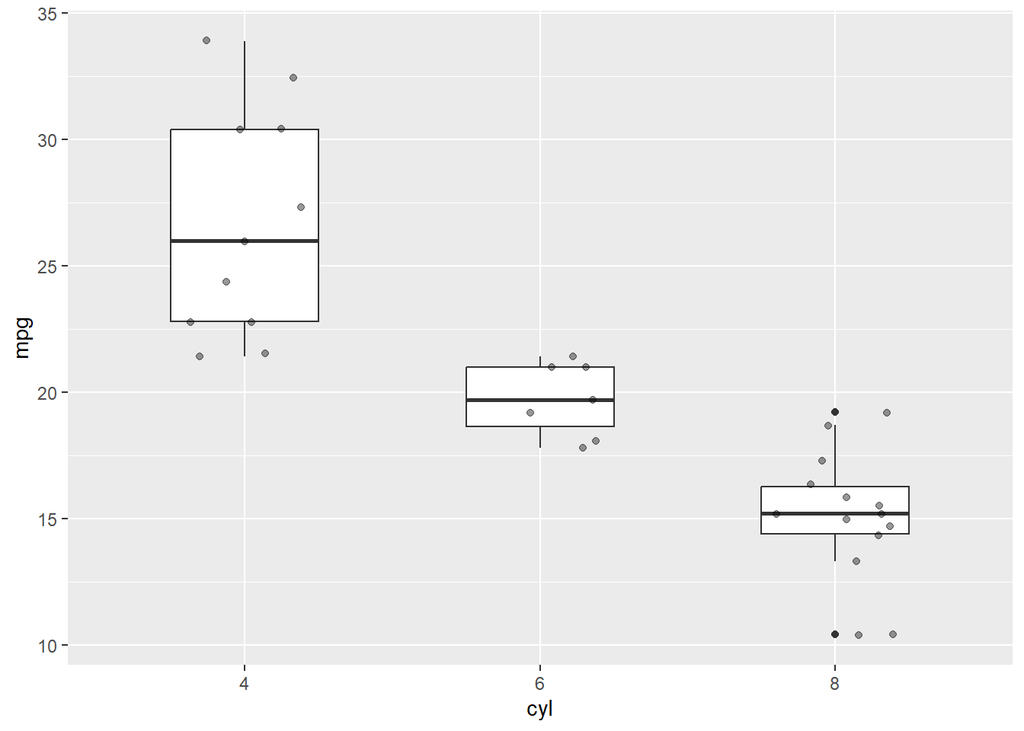

```r
ggplot(mtcars, aes(x=cyl, y=mpg)) +
  geom_boxplot(width=0.5) +
  geom_jitter(position=position_jitter(0.2), alpha=0.4)
```

Okay, now we can see where the actual values are in the distribution represented by the boxplot. The geom_jitter() function is used so that they aren’t all in a straight line through the middle of the boxplot and I use the alpha= option so the dots do not block out the boxplot itself.

Finally, let’s use the fill option to get different colors for the different values of cylinders:

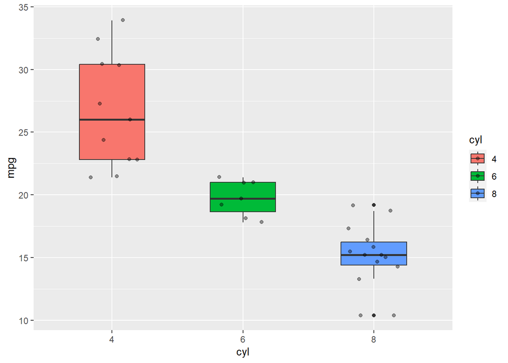

```r
ggplot(mtcars, aes(x=cyl, y=mpg, fill=cyl)) +
  geom_boxplot(width=0.5) +
  geom_jitter(position=position_jitter(0.2), alpha=0.4)
```

Notice that the positions change for the points! The geom_jitter() function adds a small randomly selected value to each point so they don’t appear all on top of one another or just in one vertical line.

We can use the set.seed() function to control this behavior so that we get the same result every time:

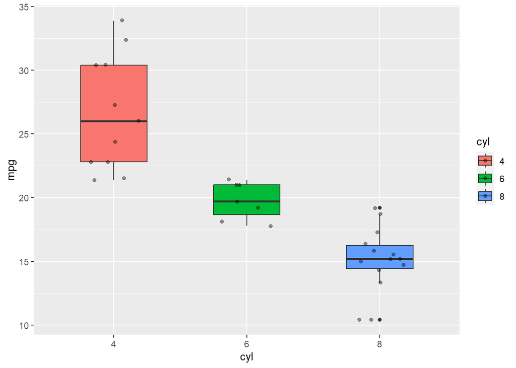

```r
set.seed(03151813)
ggplot(mtcars, aes(x=cyl, y=mpg, fill=cyl)) +
  geom_boxplot(width=0.5) +
  geom_jitter(position=position_jitter(0.2), alpha=0.4)
```

Now, no matter how many times I run that code, I get the same result!

Now, as always, let’s add some formal titles to make the graph more professional:

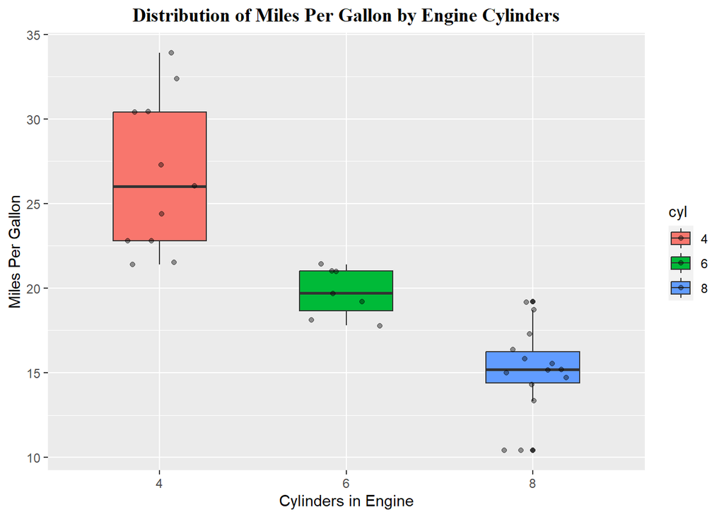

```r
set.seed(03151813)
ggplot(mtcars, aes(x=cyl, y=mpg, fill=cyl)) +
  geom_boxplot(width=0.5) +
  geom_jitter(position=position_jitter(0.2), alpha=0.4) +
  ggtitle("Distribution of Miles Per Gallon by Engine Cylinders") +
  theme(plot.title=element_text(hjust=0.5,
                                face="bold", family="serif")) +
  xlab("Cylinders in Engine") +
  ylab("Miles Per Gallon")
```

## Line Graphs

Not to be confused with lines added **to** a graph, a line graph is simply a series of connected points ordered in some way, generally by time. In fact, one of the most common ways to show the trend of something that varies over time is to use a line graph.

Let’s use some new data on the US homicide rate per year, from 1950 to 2020:

```r
year<-c(1950:2020)
hom_rate<-c(4.6, 4.4, 4.6, 4.5, 4.2, 4.1, 4.1, 4.0, 4.8, 4.9, 5.1, 4.8, 4.6,
            4.6, 4.9, 5.1, 5.6, 6.2, 6.9, 7.3, 7.9, 8.6, 9.0, 9.4, 9.8, 9.6,
            8.7, 8.8, 9.0, 9.8, 10.2, 9.8, 9.1, 8.3, 7.9, 8.0, 8.5, 8.3, 8.4,
            8.7, 9.4, 9.8, 9.3, 9.5, 9.0, 8.2, 7.4, 6.8, 6.3, 5.7, 5.5, 5.6,
            5.6, 5.7, 5.5, 5.6, 5.8, 5.7, 5.4, 5 ,4.8, 4.7, 4.7, 4.5, 4.4, 4.9,
            5.4, 5.3, 5,5, 7.8)
homicides <- data.frame(year, hom_rate)
```

Now that the data are entered, let’s make a line plot:

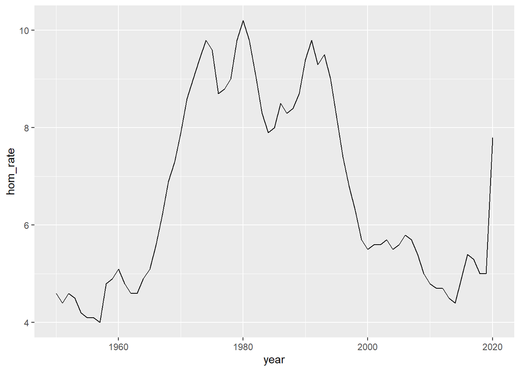

```r
ggplot(homicides, aes(x=year, y=hom_rate)) + geom_line()
```

Let’s make some adjustments to the x-axis labels to make it easier to pick out individual years. We can do this using the scale_x_continuous() function:

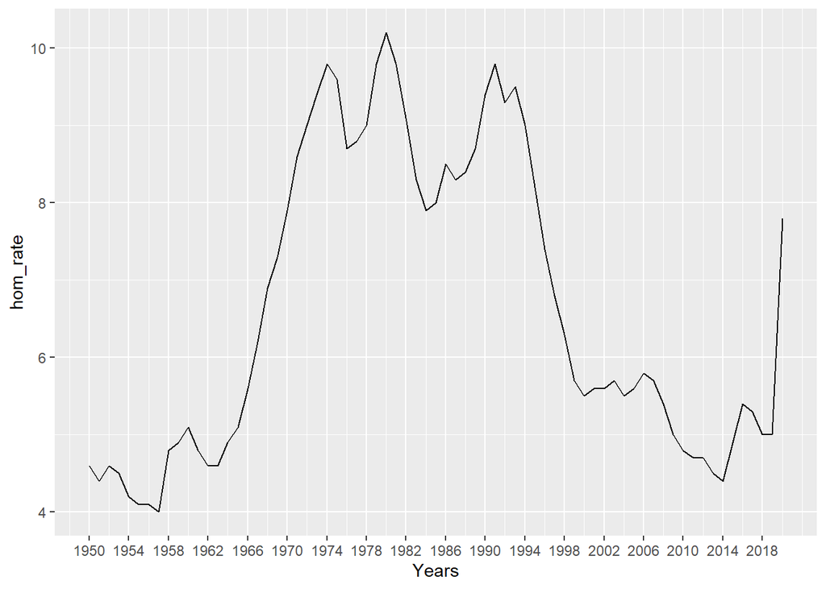

```r
ggplot(homicides, aes(x=year, y=hom_rate)) + geom_line() +
  scale_x_continuous(name="Years", breaks=seq(1950,2020, by=4))
```

That’s better, but this could look pretty jumbled if the graph was made smaller. Let’s adjust the orientation of the x-axis labels so that they’re on a slight diagonal. We can do this using the theme() function with a few options within it:

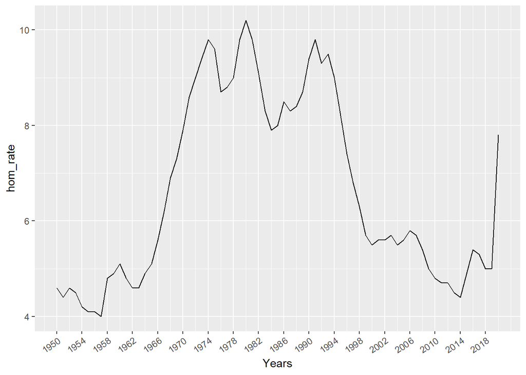

```r
ggplot(homicides, aes(x=year, y=hom_rate)) + geom_line() +
  scale_x_continuous(name="Years", breaks=seq(1950,2020, by=4)) +
  theme(axis.text.x = element_text(angle=35, hjust=1, vjust=1))
```

Much better. Now let’s do something similar for the y-axis:

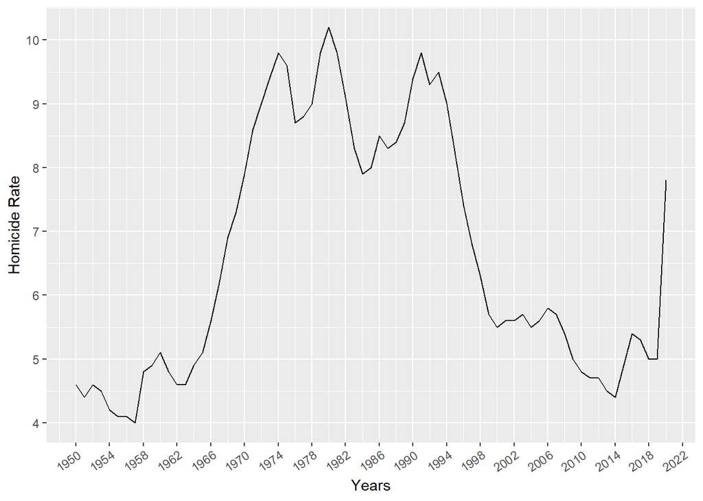

```r
ggplot(homicides, aes(x=year, y=hom_rate)) + geom_line() +
  scale_x_continuous(name="Years", breaks=seq(1950,2022, by=4)) +
  theme(axis.text.x = element_text(angle=35, hjust=1, vjust=1)) +
  scale_y_continuous(name="Homicide Rate", breaks=seq(4, 10, by=1))
```

Even better.

As always, let’s finish the graph by adding a title:

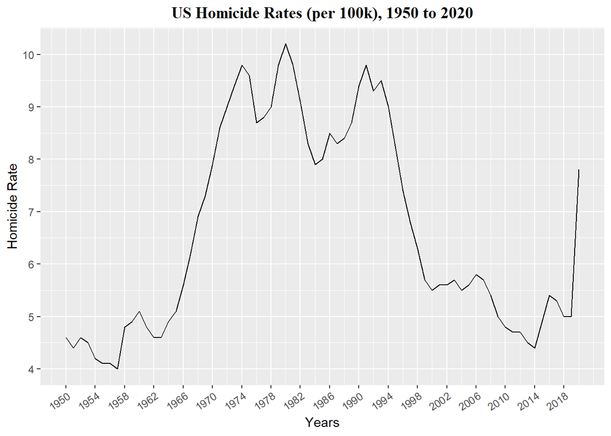

```r
ggplot(homicides, aes(x=year, y=hom_rate)) + geom_line() +
  scale_x_continuous(name="Years", breaks=seq(1950,2020, by=4)) +
  theme(axis.text.x = element_text(angle=35, hjust=1, vjust=1)) +
  scale_y_continuous(name="Homicide Rate", breaks=seq(4, 10, by=1)) +
  ggtitle("US Homicide Rates (per 100k), 1950 to 2020") +
  theme(plot.title=element_text(hjust=0.5,
                                face="bold", family="serif"))
```

## Time for your two questions!

[figure not shown]

That’s All Folks